# Going to France: Arriving to the Batelière Residence

Getting my room in the Student Residence

Nancy

going to France

Published

October 9, 2021

# Where is the Batelière Residence?

Luckily, the Residence Batelière is not far away from the IDMC or from the Nancy Gare (Main station).

[interactive chart not shown]

Their openning hours are not great (get used to that from French public institutions):

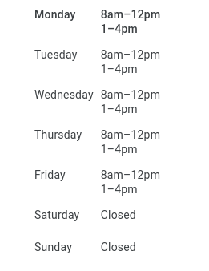

# How to get to the Residence Batelière?

Nancy happens to be a pretty walkable city (and also a very safe city!), so I could just take my luggage on foot to the Residence.

[interactive chart not shown]

The main door can only be opened with a student card or by the staff at the residence reception.

# Picking up the keys

I took one luggage first and I arrived to the residence before the time scheduled for my appointment, but they took me in anyway. The guy at the reception was a student on a summer job, and he spoke enough English to help me around.

I got two keys:

- One room key
- One mailbox key

I also got some *provisional* stuff, but I had to ask for it:

- a provisional student card which could only be used to get into the residence. I was told that after I got my own student card, I would have to return it to the reception.
- a provisional account for the WiFi network. I was told I would have to use my student email after registering at the University of Lorraine.

The guy also gave me a list of the appliances in my room, so that I could check whether or not they were in a good state. I had to return that form filled in two days.

**Important**

Finally, and this is important for a lot of bureaucracy, I received a **Certificate of Residence** (*Attestation de Residence*), which officially certifies that I lived there and contained my full address.

# The room

As it happens, when I got to the residence (the last week of August), it was almost empty, most students arrive in the middle of October. Because of this, I was able to pick my room at the residence.

If you take a second look at the map above, you will see that there is a small river in front of the residence. I picked a room with a good view to the *canal*:

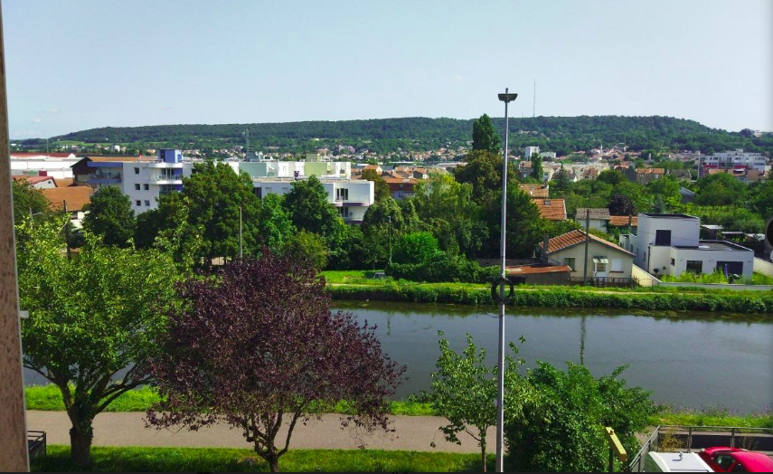

Nice view!

> The rooms at Batelière are **18 square meters**. Most other residence have rooms of 10 square meters!

Let’s take a look inside:

- View from the main door: a long table and shelves to the left and a small kitchen to the right

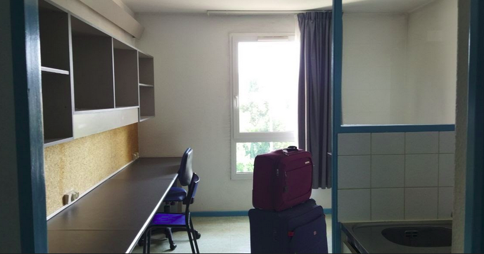

- View from the window: The long table and the shelves, a big closet behind the main door

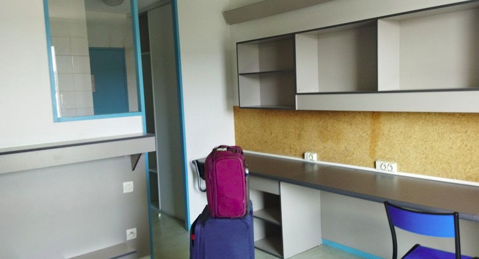

- The bathroom has a big bathtub (unlike other residences which only have small showers!)

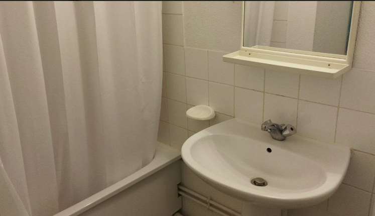

- The fridge:

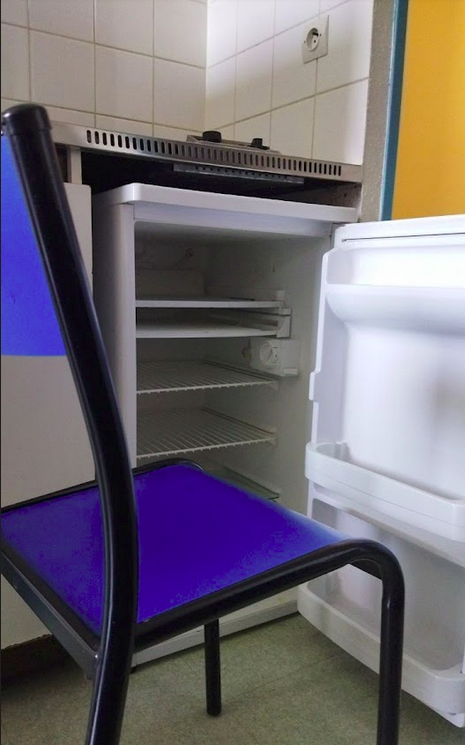

After getting the room, I had to make a second trip to get my second luggage to the residence.

As it happens, the doors at Batelière have to be locked with a special move. After trying to figure it out for a while, I asked at the reception and the guy showed me how to do it.

He was also kind enough to tell me where I could find a supermarket and some restaurants close to the residence (I will cover that on a future post.)

## Variations in the residence

I got to know this along the months I lived at Batelière. Even though most rooms are very similar, there are some subtle differences:

- Most kitchens only have one electric stove, some have two!
- Most kitchens have a tiny sink, some have a medium one
- Most beds are fixed to the wall, occasionally some rooms will have a bed that can be moved around.
- Some fridges do not have a freezer!

# The WiFi

The residence, as well as all the university buildings, uses the [`Eduroam` network](https://en.wikipedia.org/wiki/Eduroam). This is a network shared by many universities in Europe.

`Eduroam` needs a registered user name and a password to connect to the Internet. Normally, students just use their university email. However, as I had just arrived, I could not connect to it.

> Pro-tip: you can ask for a *provisional* `Eduroam` account at the reception.

I was lucky enough that, when I went down to the reception again to ask for help with the internet, they were 10 minutes from closing.

They gave me a provisional account and told me it could take a couple of hours until the database with the accounts updated.

I could only use the provisional account until I got my official account after registering at the university.

# The rent

> As of 2021, the studio rooms at Bateliềre have a rent of **418 €** per month.

Other residences have prices between 200€ and 300€.

Even though the price is steep, all students, even non-european ones, are elligible to apply for student subsidies, a topic I will cover in a future post.

# After getting the room

After getting the room, there is no time to waste for settling into a new life in France as a student of the University of Lorraine!

> At this point I had to set up via email an appointment with the Administrative Coordinator to start my registration at the Université de Lorraine. They gave me an appointment for the following week.